# bolch_hw4

https://github.com/ebolch/es207_hw4

## Helsel & Hirsch 3.1 & 3.4

3.1 Compute both nonparametric and parametric 95% interval estimates for the median of the granodiorite data of exercise 2.3. Which is more appropriate for these data? Why?

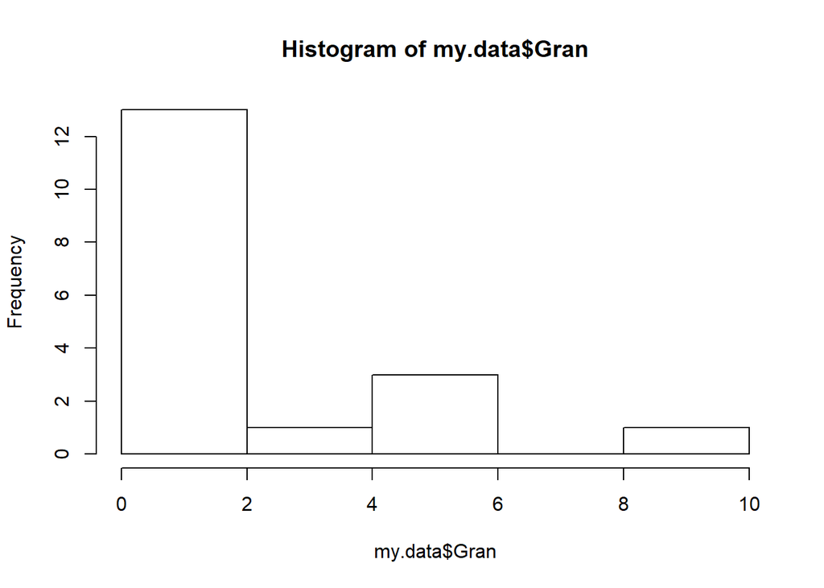

```r
#Chloride Concentrations (mg/L)
my.data <- tibble(
  Gran = c(6.0, 0.4, 0.4, 0.7, 0.8, 6.0, 5.0, 0.6, 1.2, 0.3, 0.2, 0.5, 0.5, 10, 0.2, 0.2, 1.7, 3.0),
  Qtz_M = c(1.0, 0.2, 1.2, 1.0, 0.3, 0.1, 0.1, 0.4, 3.2, 0.3, 0.4, 1.8, 0.9, 0.1, 0.2, 0.3, 0.5, NA))
hist(my.data$Gran)
```

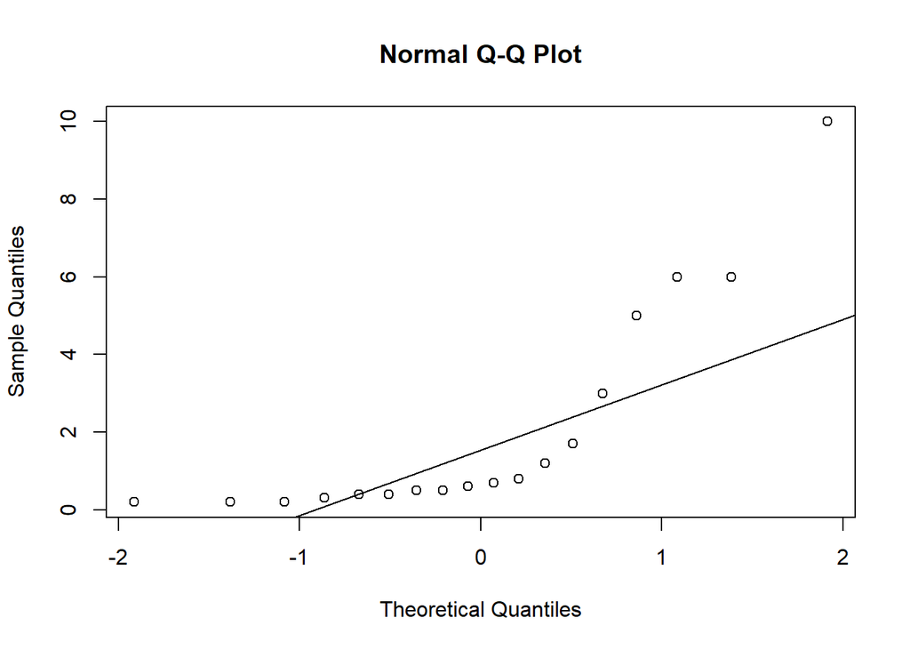

```r
qqnorm(my.data$Gran)
qqline(my.data$Gran)
```

Non-Parametric

```r
#Non-Parametric Prediction Interval
mednppi <- function(x,y){# requires data vector and alpha
  x <- sort(x)
  print(x)
  med <- median(x)
  print(med)
  alpha <- y
  xprime <- qbinom(alpha/2, size = length(x), prob = 0.5)# 0.5 is for median of small sample sizes
  Rl <- xprime + 1
  Ru <- length(x) - xprime
  print(paste("True median falls within", x[Rl], "to", x[Ru], "at", 100*(1-alpha), "% Confidence Interval"))
}

mednppi(my.data$Gran, 0.05)
```

```
##  [1]  0.2  0.2  0.2  0.3  0.4  0.4  0.5  0.5  0.6  0.7  0.8  1.2  1.7  3.0
## [15]  5.0  6.0  6.0 10.0
## [1] 0.65
## [1] "True median falls within 0.4 to 1.7 at 95 % Confidence Interval"
```

Parametric

```r
#t values required. values calculated from t.test(function of mean?) were different book example
medppi <- function(x,a,t){
  alpha <- a
  n <- length(x)
  y <- log(x)
  ybar <- mean(y)
  GM<- exp(ybar) #Geometric Mean of Log transform is approximation of median if they are symmetric
  s <- sd(y)
  Rl <- exp(ybar-t*sqrt(s^2/n))
  Ru <- exp(ybar+t*sqrt(s^2/n))
  print(paste("True median falls within", Rl, "to", Ru, "at", 100*alpha, "% Confidence Interval"))
}
t<- 2.110 #for .05 two tail, df = 17
medppi(my.data$Gran, 0.95, t)
```

```
## [1] "True median falls within 0.498282623872728 to 1.78893578007132 at 95 % Confidence Interval"
```

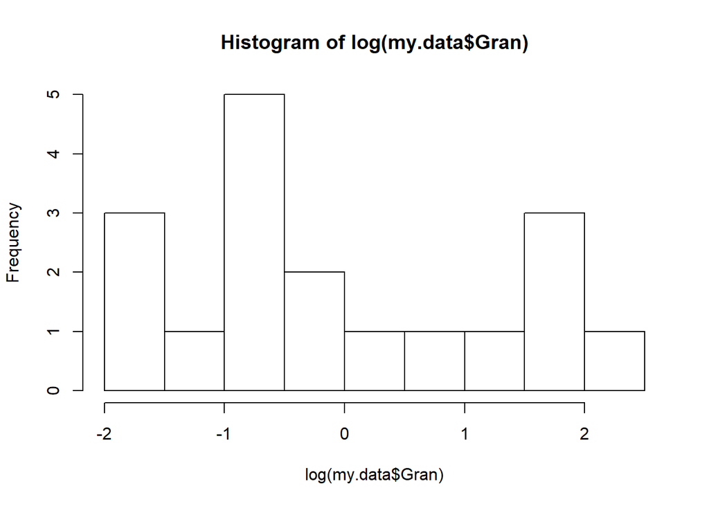

```r
hist(log(my.data$Gran))
```

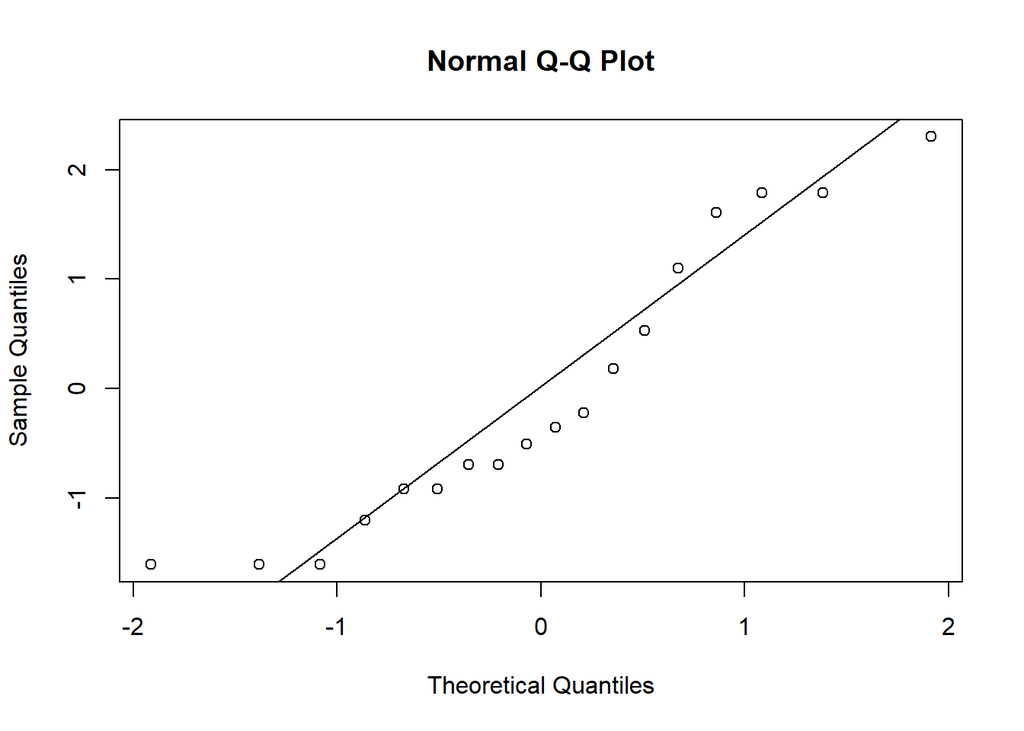

```r
qqnorm(log(my.data$Gran))
qqline(log(my.data$Gran))
```

A non-parametric interval estimate is probably more appropriate for this data due to its skewed distribution. However the distribution of the log appears to be a normal distribution, so it’s also possible to use the parametric interval estimate.

3.4 Construct the most appropriate 95 percent interval estimates for the mean and median annual streamflows for the Conecuh River at Brantley, Alabama (data in Appendix C2).

```r
C2 <- read_csv("./data/Conecuh_River_apxc2.csv")
head(C2)
```

```
## # A tibble: 6 x 2
##    Year `Flow (cfs)`
##   <dbl>        <dbl>
## 1  1941          369
## 2  1942          683
## 3  1943          923
## 4  1944         1193
## 5  1945          413
## 6  1946         1025
```

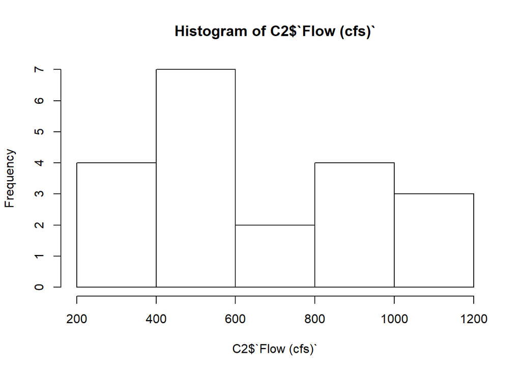

```r
hist(C2$`Flow (cfs)`)
```

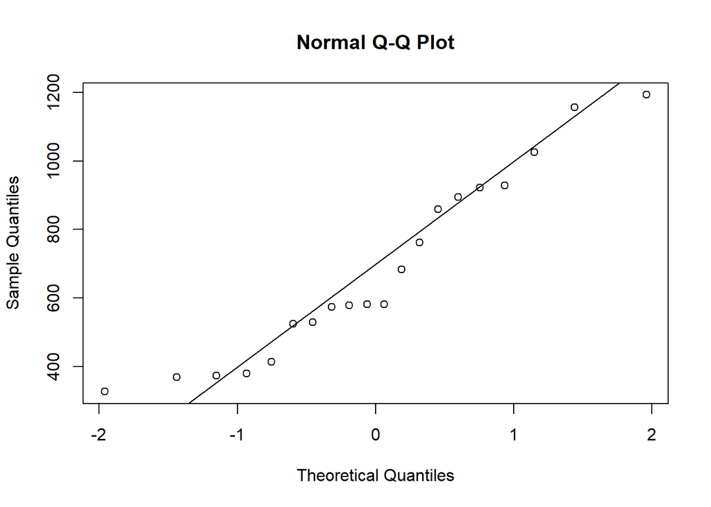

```r
qqnorm(C2$`Flow (cfs)`)
qqline(C2$`Flow (cfs)`)
```

Median

```r
mednppi <- function(x,y){# requires data vector and alpha
  x <- sort(x)
  print(x)
  med <- median(x)
  print(med)
  alpha <- y
  xprime <- qbinom(alpha/2, size = length(x), prob = 0.5)# 0.5 is for median of small sample sizes
  Rl <- xprime + 1
  Ru <- length(x) - xprime
  print(paste("True median falls within", x[Rl], "to", x[Ru], "at", 100*(1-alpha), "% Confidence Interval"))
}

mednppi(C2$`Flow (cfs)`, 0.05)
```

```
##  [1]  327  369  374  379  413  524  530  574  578  581  581  683  762  859
## [15]  894  923  929 1025 1157 1193
## [1] 581
## [1] "True median falls within 530 to 859 at 95 % Confidence Interval"
```

Mean

```r
t.test(C2$`Flow (cfs)`,conf.level = 0.95)
```

```
##
##  One Sample t-test
##
## data:  C2$`Flow (cfs)`
## t = 11.329, df = 19, p-value = 6.803e-10
## alternative hypothesis: true mean is not equal to 0
## 95 percent confidence interval:
##  556.6132 808.8868
## sample estimates:
## mean of x
##    682.75
```

## Qian Ch.4 Problem 4

The Everglades wetland ecosystems are phosphorus limited. After the Everglades Agriculture Areas (EAA) were established (enabled by a series of federal government constructed water diversion systems for draining part of the Everglades wetland), phosphorus-rich agriculture runoff reached the Everglades wetland and resulted in dramatic changes in parts of the Everglades wetlands. To better protect the Everglades, many studies were conducted in the late 1980s and the 1990s to learn about the effects of phosphorus enrichment in the Everglades. One study focused on estimating the background level of phosphorus concentration. To identify which site is not affected by the agriculture runoff, researchers measured phosphatase activity (APA) in sites known to be affected (TP > 30 microg/L) and sites that are unaffected by agriculture runoff. Phosphatase is an enzyme produced by organisms in low P environment. Because producing this enzyme costs energy, organisms do not produce them when bio-available phosphorus are present. As a result, high APA is an indicator of P limitation. The data file apa.s contains both APA and TP concentrations. It can be imported into R using function source.

```r
source("./data/apa.s")
```

(a) Compare the distributions of APA from sites with TP > 30 microg/L and APA from sites with TP < 30 microg/L using graphical tools we learned in Chapter 3.

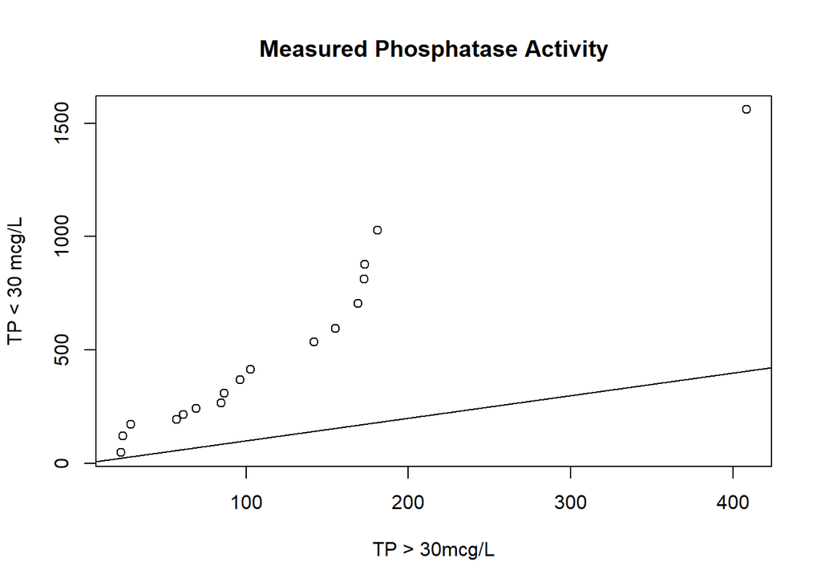

```r
hi.tp <- filter_at(apa.dat, vars(tp), ~. >30)
low.tp <- filter_at(apa.dat, vars(tp), ~. <30)
qqplot(hi.tp$apa,low.tp$apa, xlab = "TP > 30mcg/L", ylab = "TP < 30 mcg/L", main = "Measured Phosphatase Activity")
abline(0,1)
```

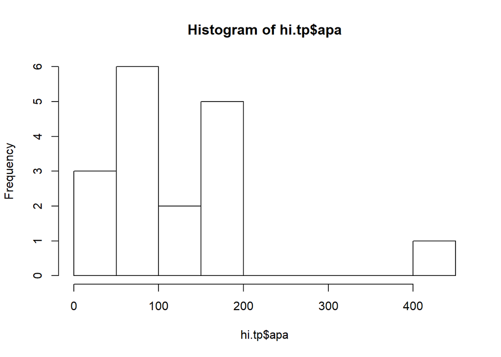

```r
hist(hi.tp$apa)
```

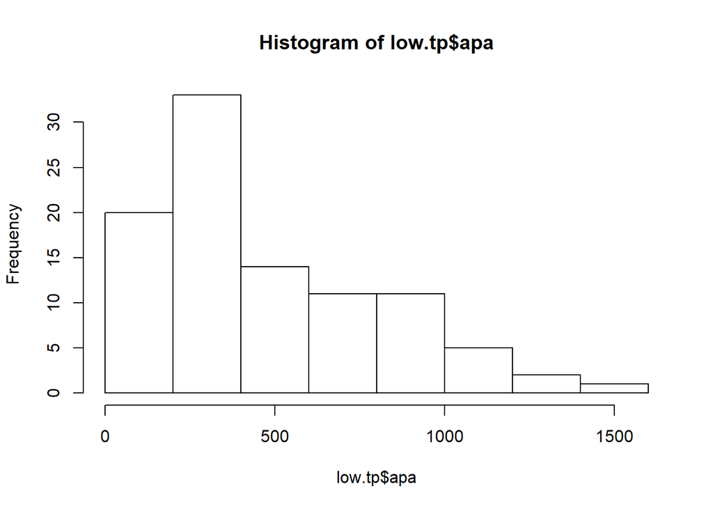

```r
hist(low.tp$apa)
```

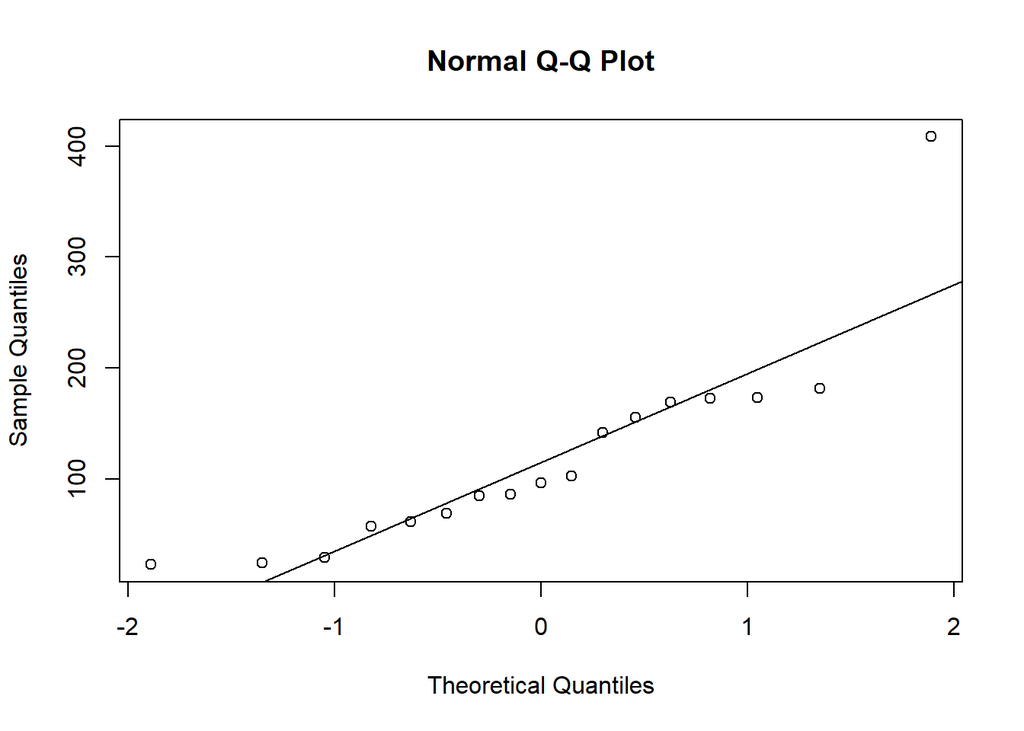

```r
qqnorm(hi.tp$apa)
qqline(hi.tp$apa)
```

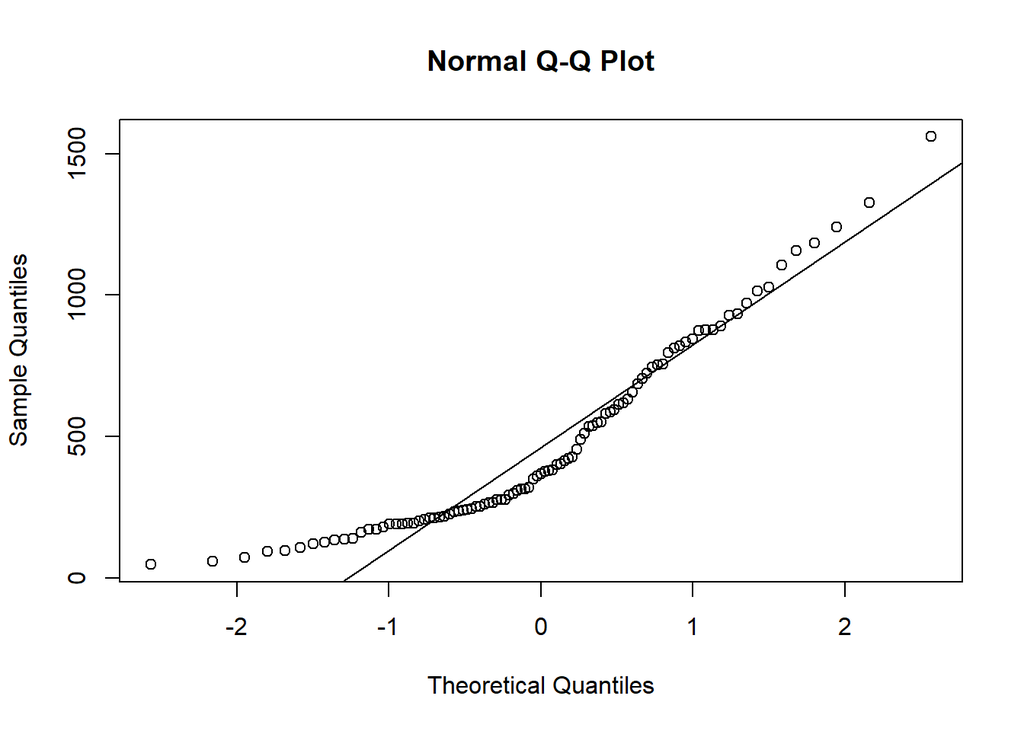

```r
qqnorm(low.tp$apa)
qqline(low.tp$apa)
```

From the first QQplot of TP > 30 vs TP < 30, its clear the distributions are multiplicative, indicating that a log transform could possibly be used to change it to additive, or that a non-parametric test is needed to adequately compare the data.

(b) What is the nature of difference between the two populations of APA?

```r
sd(hi.tp$apa)
```

```
## [1] 92.42849
```

```r
sd(low.tp$apa)
```

```
## [1] 331.9719
```

```r
ltlow <- log(low.tp$apa)
lthi <- log(hi.tp$apa)
sd(ltlow)
```

```
## [1] 0.7551351
```

```r
sd(lthi)
```

```
## [1] 0.7847718
```

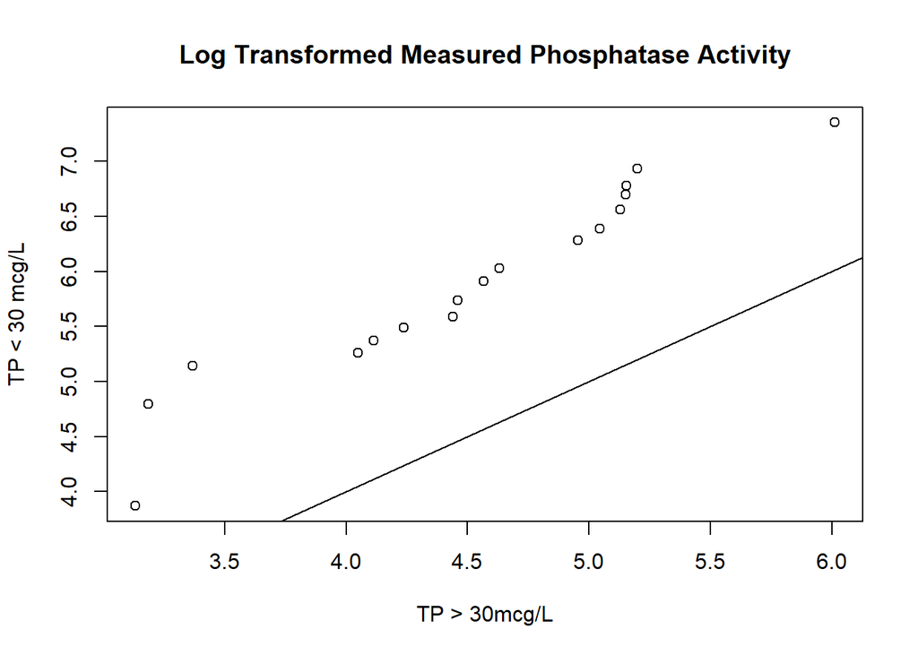

```r
qqplot(lthi,ltlow, xlab = "TP > 30mcg/L", ylab = "TP < 30 mcg/L", main = "Log Transformed Measured Phosphatase Activity")
abline(0,1)
```

(c) Use an appropriate test to determine whether the difference is statistically significant and describe the result in non-technical terms.

```r
require(exactRankTests)
wilcox.exact(low.tp$apa, hi.tp$apa, conf.int = T)
```

```
##
##  Asymptotic Wilcoxon rank sum test
##
## data:  low.tp$apa and hi.tp$apa
## W = 1499, p-value = 8.071e-08
## alternative hypothesis: true mu is not equal to 0
## 95 percent confidence interval:
##  156.477 432.107
## sample estimates:
## difference in location
##               248.1801
```